# `Prosper Loan Dataset Exploration`

## Multivariate Exploration

### 1. Employment Status and Loan Original Amount vs Loan Status :

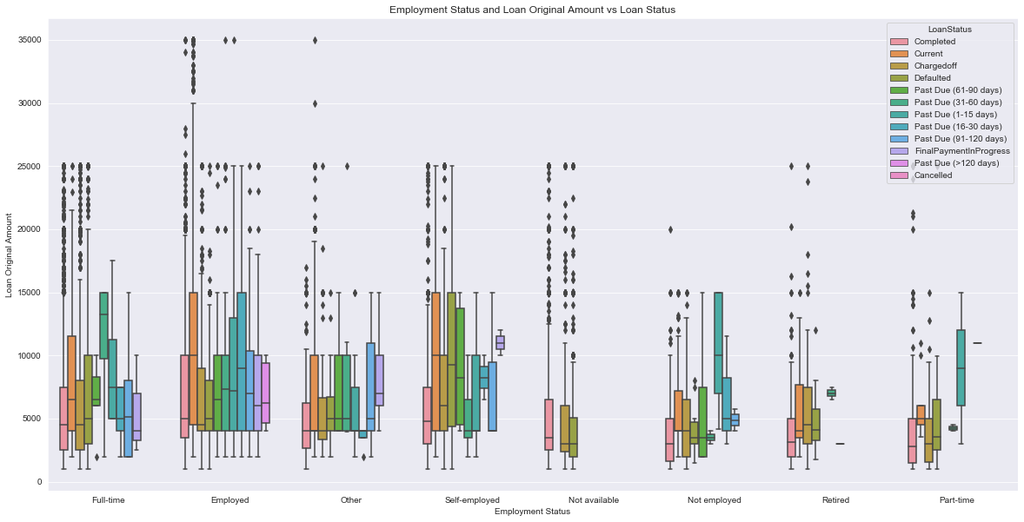

```python
plt.figure(figsize = [20,10])
sb.boxplot(data = df_subset, x = 'EmploymentStatus',
            y = 'LoanOriginalAmount', hue = "LoanStatus")

lables_name('Employment Status', 'Loan Original Amount')
plt.title('Employment Status and Loan Original Amount vs Loan Status');
```

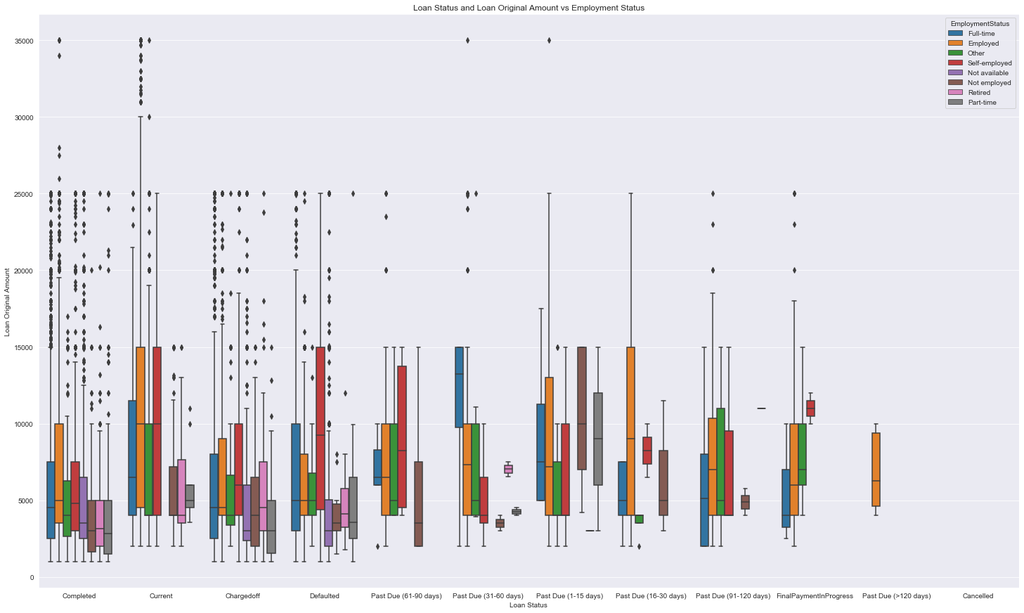

```python
plt.figure(figsize = [25,15])
sb.boxplot(data = df_subset, x = 'LoanStatus',
            y = 'LoanOriginalAmount', hue = "EmploymentStatus");

lables_name('Loan Status', 'Loan Original Amount')
plt.title('Loan Status and Loan Original Amount vs Employment Status');
```

### Observation :

- Completed Loan are the lowest .
- Currently Active loans are highest .
- Self - Employed are largest .

### 2 . Loan Origination Year and ListingCategory (numeric) vs Loan Status

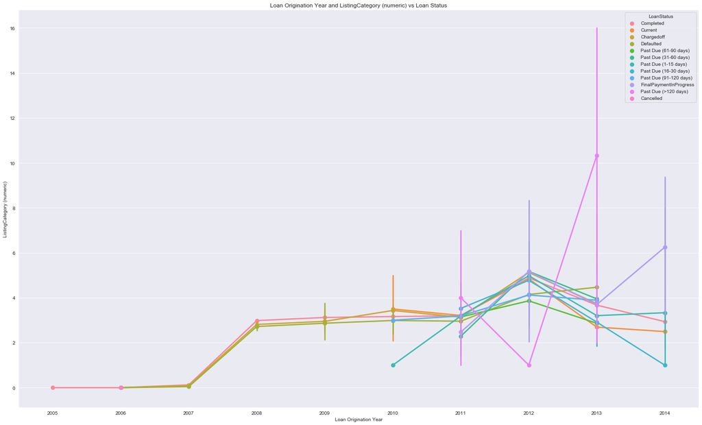

```python
plt.figure(figsize = [25,15])
sb.pointplot(data = df_subset, x = 'Originationyear',
            y = 'ListingCategory (numeric)', hue = "LoanStatus");

lables_name('Loan Origination Year', 'ListingCategory (numeric)')
plt.title('Loan Origination Year and ListingCategory (numeric) vs Loan Status');
```

### 3. Prosper Rating and Employment Status vs Loan Status

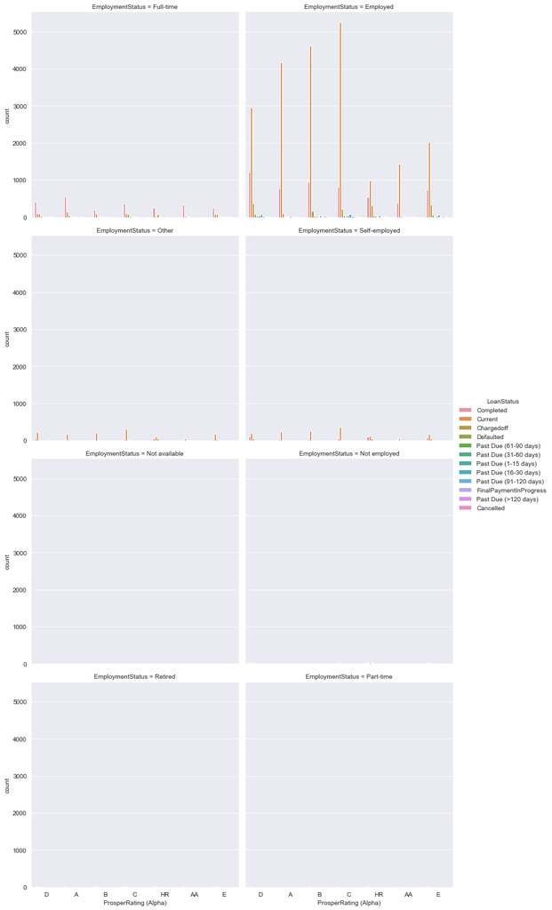

```python
# plt.figure(figsize = [,15])
sb.catplot(data = df_subset , x = 'ProsperRating (Alpha)', col = 'EmploymentStatus', hue = 'LoanStatus'
              , kind = 'count', col_wrap = 2);
```

### Observation :

- Employed Borrowers are the highest with Prosper Rating and Completed Loan
- also with Currently Active Loans .

### 4. Numerical Category Variables :

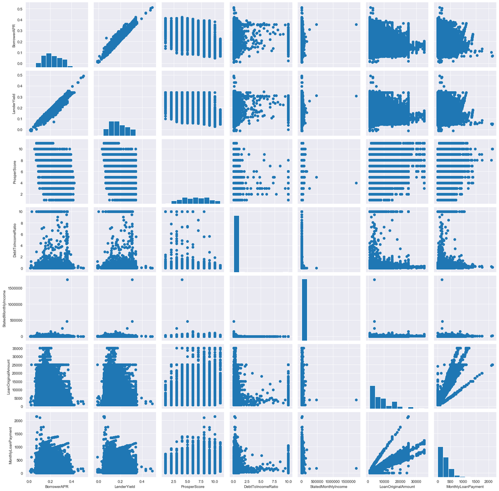

```python
df_stats = ['BorrowerAPR', 'LenderYield', 'ProsperScore', 'DebtToIncomeRatio',
               'StatedMonthlyIncome', 'LoanOriginalAmount', 'MonthlyLoanPayment']
ax = sb.PairGrid(data = df_subset , vars = df_stats)
ax = ax.map_offdiag(plt.scatter)
ax.map_diag(plt.hist);
```

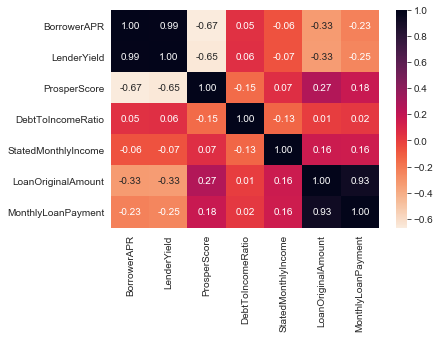

```python
df_stats = ['BorrowerAPR', 'LenderYield', 'ProsperScore', 'DebtToIncomeRatio',
               'StatedMonthlyIncome', 'LoanOriginalAmount', 'MonthlyLoanPayment']
sb.heatmap(df_subset[df_stats].corr() , cmap = 'rocket_r' , annot =True , fmt = '.2f');
```

### Observation :

- LoanOriginalAmount and BorrowerAPR is having negative relationship
- BorrowerAPR and LenderYield is having strong positive relationship
- ProsperScore and BorrowerAPR is having Negative relationship
- LoanOriginalAmount and MonthlyLoanPayment is having strong positive relationship

### Were there any interesting or surprising interactions between features?

> Prosper Rating and Employment Status : Non- Employed have the lowest rating , Employed have the highest rating .